# Topic 2: Linear Regression

Math 253: Statistical Computing & Machine Learning

Daniel Kaplan

## Day 4 Preview

- The linear model (e.g. what `lm()` does)
- A variety of questions relevant to different purposes, e.g.
  - how good will a prediction be?
  - what’s the strength of an effect?
  - is there synergy between different factors?

ISL book’s statement on why to study linear regression

> “Though it may seem somewhat dull compared to some of the more modern statistical learning approaches described … later …, linear regression is still a useful and widely used statistical learning method. Moreover, it serves as a good jumping-off point for newer approaches…. Consequently, the importance of having a good understanding of linear regression before studying more complex learning methods cannot be overstated.”

Concepts from linear regression:

- Compact representation of model form: polynomial coefficients.
- Much of inference (confidence intervals, hypothesis tests) can be expressed in terms of a polynomial coefficient.
- “Size” of model quantifiable as an integer: number of coefficients: degrees of freedom.
- Highly efficient estimation (when doing least squares)

## Small data

The regression techniques were developed in an era of small data, such as that that might be written in a lab notebook or field journal. As a result:

1. Emphasis on very simple descriptions, such as means, differences between means, simple regression.
2. Theoretical concern with details of distributions, such as the t-distribution.
   - the difference between z- and t-distributions are of no consequence for moderate DF and higher.
3. No division into training and testing data. Data are too valuable to test! (Ironic, given the importance of replicability in the theory of the scientific method.)

As a consequence of (3), there’s a great deal of concern about *assumptions*, e.g.

- linearity of $f({\mathbf X})$
- structure of $\epsilon$: IID — Independent and Identically Distributed
  - uncorrelated between cases
  - each is a draw from the same distribution.

## Review of Day 4, Sept 15, 2017

- How the linear regression architecture relates to machine learning.
  - linear regression is designed to work even in “small data” situations where
    1. cross-validation is not appropriate
    2. the number of model degrees of freedom may be almost as large as $n$
  - provides a ready definition of the “size” of a model: the number of coefficients.
- Main software used in linear regression, `lm()` and `predict()`
- Programming basics: indexing of vectors, matrices and data frames.

## Regression and Interpretability

Regression models are generally constructed for the sake of interpretability:

- Global linearity
- Coefficients are indication of effect size. The coefficients have physical units.
- Term by term indication of statistical significance

An example on `College` data from `ISLR` package

```r
data(College, package="ISLR")
College$Yield <- with(College, Enroll/Accept)
mod1 <- lm(Yield ~ Outstate + Grad.Rate + Top25perc, data = College)
mosaic::rsquared(mod1)
```

```
## [1] 0.2170221
```

```r
mod2 <- lm(Yield ~ . - Grad.Rate, data = College)
mosaic::rsquared(mod2)
```

```
## [1] 0.5004599
```

- What variables matter?
- How good are the predictions?
- How strong are the effects?

## Toward an automated regression process

In machine learning, we ask the computer to identify patterns in the data.

- In “traditional” regression (which is still very important), we specify the explanatory terms and the computer finds the “best” model with those terms: least squares.
- In machine learning, we want the computer to figure out which terms, of all the possibilities, will lead to the “best” model.

## Selecting model terms

```r
explanatory_vars <- names(College)[-19]

my_vars <- sample(explanatory_vars, size = 12)
new_data <- College[ , c(my_vars, "Yield")]
mod <- lm(Yield ~ ., data = new_data)
mosaic::rsquared(mod)
```

```
## [1] 0.4520327
```

```r
mod
```

```
##
## Call:
## lm(formula = Yield ~ ., data = new_data)
##
## Coefficients:
## (Intercept)          PhD  perc.alumni    Top25perc       Expend
##   5.593e-01   -8.842e-04   -7.902e-04   -2.864e-04   -1.227e-06
##   Top10perc   PrivateYes     Terminal    S.F.Ratio  F.Undergrad
##   4.940e-04   -3.107e-02   -7.833e-04    2.505e-03   -4.859e-06
##      Enroll         Apps       Accept
##   2.149e-04    1.438e-05   -9.607e-05
```

```r
2^18
```

```
## [1] 262144
```

- Activity 2: * How many combinations are there of $k$ explanatory variables? Calculate this for $k = 5, 10, 15, 20$. How many are there in the `College`? * What about with interactions?
- How long does it take to fit a model?

```r
system.time( do(1000) * lm(Yield ~ ., data=College))
```

```
##    user  system elapsed
##   8.410   0.076   8.545
```

```r
256*7/3600
```

```
## [1] 0.4977778
```

```r
names(College)
```

```
##  [1] "Private"     "Apps"        "Accept"      "Enroll"      "Top10perc"
##  [6] "Top25perc"   "F.Undergrad" "P.Undergrad" "Outstate"    "Room.Board"
## [11] "Books"       "Personal"    "PhD"         "Terminal"    "S.F.Ratio"
## [16] "perc.alumni" "Expend"      "Grad.Rate"   "Yield"
```

## Programming basics: Graphics

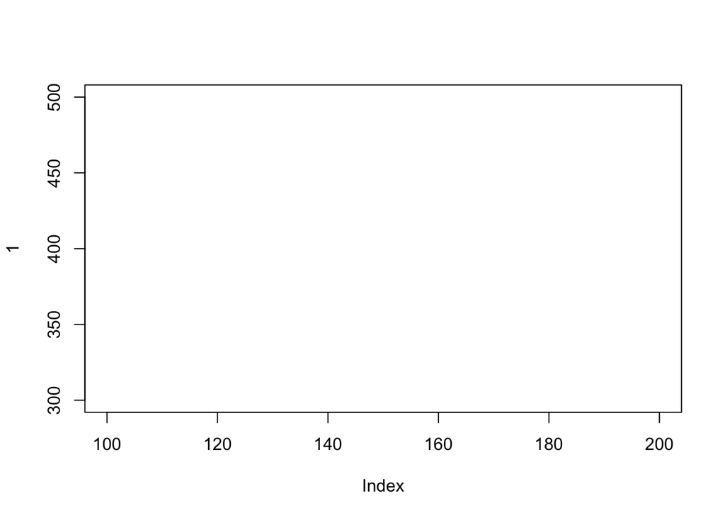

```r
plot(1, type = "n", xlim = c(100,200), ylim = c(300,500))
```

Basic functions:

1. Create a frame: `plot()`. Blank frame: `plot( , type="n")`
   - set axis limits,
2. Dots: `points(x, y)`, `pch=20`
3. Lines: `lines(x, y)` — with `NA` for line breaks
4. Polygons: `polygon(x, y)` — like lines but connects first to last.
   - fill
5. Color, size, … `rgb(r, g, b, alpha)`, “tomato”

## In-class programming activity

Programming Activity 4: Drawing a histogram.

## Day 5 Summary

### Linear regression

- Discussed “interpretability” of linear models, e.g. meaning of coefficients, confidence intervals, R^2, etc.
  - which variables are “important” via ANOVA and mean sum of squares
- Discussed metrics to compare models
  - R^2 – not fair, since “bigger” models are always better
  - Punishment: Two criteria for judging
    - R^2
    - How big the model is.
    - These two are somehow combined together into “adjusted R^2.” We’ll say more about that today.
  - Cross-validation. Judge each model on its “out of sample” prediction performance.

### Coefficients as quantities

Coefficients in linear models are not just numbers, they are physical quantities with dimensions and units.

- Dimensions are always (dim of response)/(dim of this term)
- The model doesn’t depend on the units of these quantities. The units only set the magnitude to the numerical part of the coefficient, but as a quantity a coefficient is the same thing regardless of units.
- Conversion from one unit to another by multiplying by 1, but expressed in different units, e.g. 60 seconds per minute, 2.2 pounds per kilogram.

## In-class programming activity

Day 5 activity

Drawing a histogram.

## Measuring Accuracy of the Model

- $R^2$ = Var(fitted)/Var(response)
- Adjusted $R^2$ - takes into account estimate of average increase in $R^2$ per junk degree of freedom
- Residual Standard Error - Sqrt of average square error per residual degree of freedom. The sqrt of the mean square for residuals in ANOVA.

## Bias of the model

You need to know the “truth” to calculate the bias. We don’t.

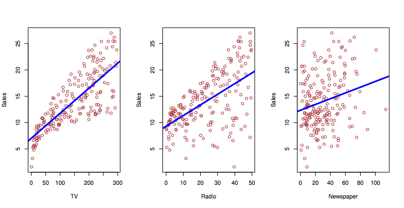

- Perhaps effect of TV goes as sqrt(money) as media get saturated?
- Perhaps there is a synergy that wasn’t included in the model?

### Theory of whole-model ANOVA.

Standard measure: $\frac{\mbox{Explained amount}}{\mbox{Unexplained amount}}$

Examples:

- Standard error of mean: $\frac{\hat{\mu}}{\sigma / n}$ – note the $n$.
- t statistic on difference between two means: $\frac{\hat{\mu}_1 - \hat{\mu}_2}{\sigma / (n-1)}$
- F statistic: $\frac{SS / df1}{SSR / df2}$
  - df1 is the number of degrees of freedom involved by the model or model term under consideration.
  - df2 is $n - (p - 1)$ where $p$ is the total degrees of freedom in the model. (I called this $m$ in the Math 155 book.) The intercept is what the $-1$ is about: the intercept *can never* account for case-to-case variation.

Trade-off between eating variance and consuming degrees of freedom.

## Forward, backward and mixed selection

Use the `College` model to demonstrate each of the approaches by hand. Start with `pairs()` or write an `lapply()` for the correlation with `Yield`?

Create a whole bunch of model terms

- “main” effects
- “interaction” effects
- nonlinear transformations: powers, logs, sqrt, steps, …
- categorical variables

Result: a set of $k$ vectors that we’re interested to use in our model.

Considerations:

- not all of the $k$ vectors may pull their weight
- two or more vectors may overlap in how they eat up variance

Algorithmic approaches:

- Try all combinations, pick the best one.
  - computationally expensive/impossible $2^k$ possibilities
  - what’s the sensitivity of the process to the choice of training data?
- “Greedy” approaches

## Programming Basics: Functions

1. Syntax of functions:

   ```r
   name <- function(arg1, arg2, ...) {
     body of function. Can use arg1, arg2, etc.
   }
   ```

- typically you will return a value. The value calculated by the last command line in the body is what’s returned. Or you can use `return()` at any point in the function.
- Often functions are designed to produce “side effects”, e.g. graphics.
- Scope: what happens in functions stays in functions.
1. Create a plotting frame: `plot()`
   - Write a function that makes this more convenient to use. What features would you like.

   ```r
   blank_frame <- function(xlim, ylim) {

   }
   ```

2. Write a function to draw a circle.
   - What do you want the interface to look like? What arguments are essential? What options are nice to have?

## In-class programming activity

Histogram and density functions

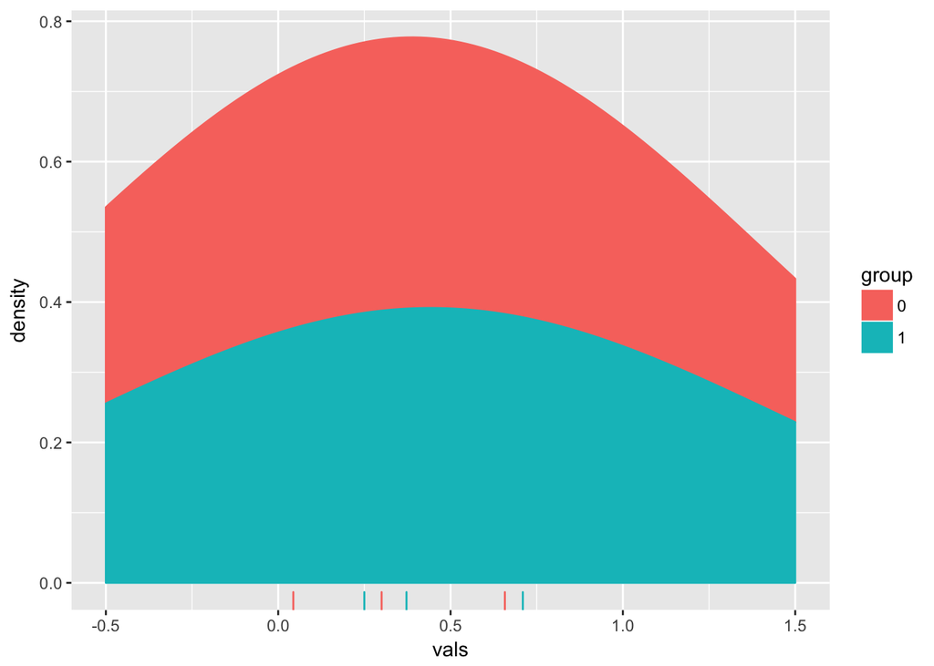

```r
set.seed(101)
n = 20
X <- data.frame(vals = runif(n),
                group = as.character((1:n) %% 2))
ggplot(head(X, 6), aes(x = vals)) +
  geom_density(bw = 1, position = "stack", aes(color = group, fill = group)) +
  geom_rug(aes(color = group)) +
 # facet_grid( . ~ group) +
  xlim(-0.5, 1.5)
```

Day 6 activity

## Review of Day 7

- We finished reviewing adjusted R^2 and ANOVA.
- Started talking about linear algebra.

We only got through the first few elements in our review of linear algebra. Let’s go through them again

## Using predict() to calculate precision

- confidence intervals
- prediction intervals

## Conclusion

This wraps up our look at linear regression. Main points:

- model output is a linear combination of the inputs.
- `lm()` finds the “best” linear combination.
- rich theory relating to precision of coefficients and the residuals.
- traditional ways of applying that theory: F tests and t tests.